# Module8

Natalie Robinson

September 25, 2017

# Homework Problem:

Every Saturday, at the same time, a primatologist goes and sits in the forest in the morning and listens for titi monkey calls, counting the number of calls they hear in a 2 hour window from 5am to 7am. Based on previous knowledge, she believes that the mean number calls she will hear in that time is exactly 15. Let X represent the appropriate Poisson random variable of the number of calls heard in each monitoring session.

What is the probability that she will hear more than 8 calls during any given session?

```r
x <- 8
l <- 15
probset1 <- 1- ppois(x, l)
probset1
```

```
## [1] 0.9625535
```

What is the probability that she will hear no calls in a session?

```r
x <- 0
l <- 15
probset2 <- dpois(x, l)
probset2
```

```
## [1] 3.059023e-07
```

What is the probability that she will hear exactly 3 calls in a session?

```r
x <- 3
l <- 15
probset3 <- dpois(x, l)
probset3
```

```
## [1] 0.0001720701
```

Plot the relevant Poisson mass function over the values in range 0 ≤ X ≤ 30.

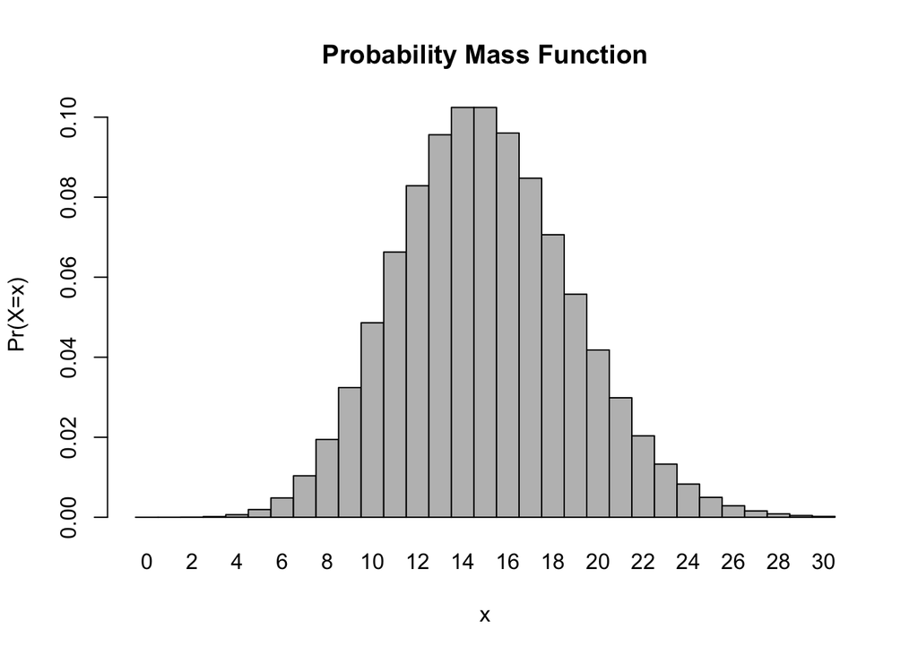

```r
x <- 0:30
l = 15
graphprobset <- dpois(x = x, lambda = l)
barplot(graphprobset, names.arg = x, space = 0, xlab = "x", ylab = "Pr(X=x)", main = "Probability Mass Function")
```

Simulate 104 results from this distribution (i.e., 2 years of Saturday monitoring sessions).

```r
n <- 104
l <- 15
results <- rpois(n = n, lambda = l)
results
```

```
##   [1] 11 14 14 12 13 19 11  9 18 18 22 13 16 15 22 13 20 16 13 19 18 18 12
##  [24] 13 11 18 18  9 12 12 17 25 11 13 18 14 19 13 14 18 15 17 13 14 10 12
##  [47]  9 18 14 13 14 11 20 19 15 15 24 20 18  8  8 11 24 19 10 10 12 15 23
##  [70] 12 18 20  6 12 15 21 16 19 14 15 12 12 24 10 21 17 18 12  8 17 19 12
##  [93] 14 13 13 13 18 16 16 12 16  9 17 20
```

Plot the simulated results using hist() and use xlim() to set the horizontal limits to be from 0 to 30.

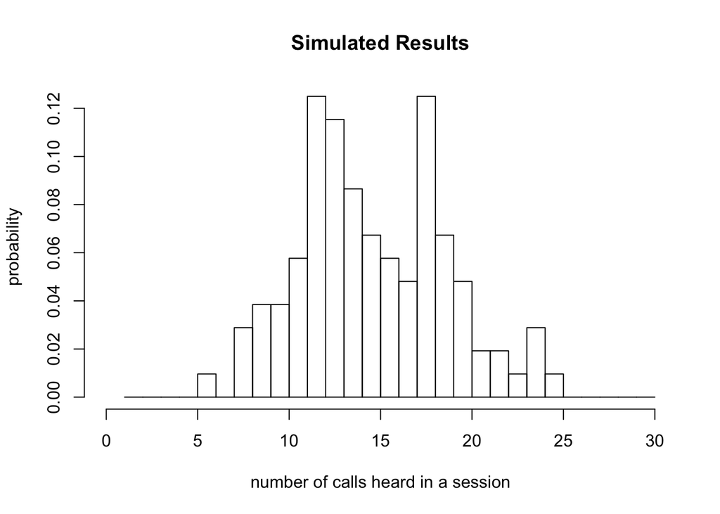

```r
hist(results, xlim = c(0,30), probability = TRUE, breaks = c(1:30), main = "Simulated Results",
    xlab = "number of calls heard in a session", ylab = "probability")
```

How does your histogram compare to the shape of the probability mass function you plotted above?